# HW3_송영국

## 1. Calibration에 사용된 알고리즘

#### Levenberg-Marquardt (LM) 알고리즘

1. 비선형 최적화 문제에 많이 사용
2. Jacobian을 활용하여, 빠른 수렴과 안정성이 높음.

#### 코드

> res = least_squares(residuals, x0, method='lm')

초기값과 잔차를 입력받아 LM 알고리즘으로 계산

```python
from scipy.optimize import least_squares
import numpy as np
import scipy.io
import matplotlib.pyplot as plt
from scipy.optimize import minimize


# 데이터 로드
data = scipy.io.loadmat('robot_data.mat')
theta1_train = data['theta1_train'].flatten()
theta2_train = data['theta2_train'].flatten()
p_train = data['pTrain'][:2, :]  # (2 x N)


# Forward Kinematics
def forward_kinematics(theta1, theta2, a1, a2):
    x = a1 * np.cos(theta1) + a2 * np.cos(theta1 + theta2)
    y = a1 * np.sin(theta1) + a2 * np.sin(theta1 + theta2)
    return np.vstack((x, y))  # 2 x N
```

```
Calibration 전:
평균 오차 (m): 0.0972
최대 오차 (m): 0.1112
```

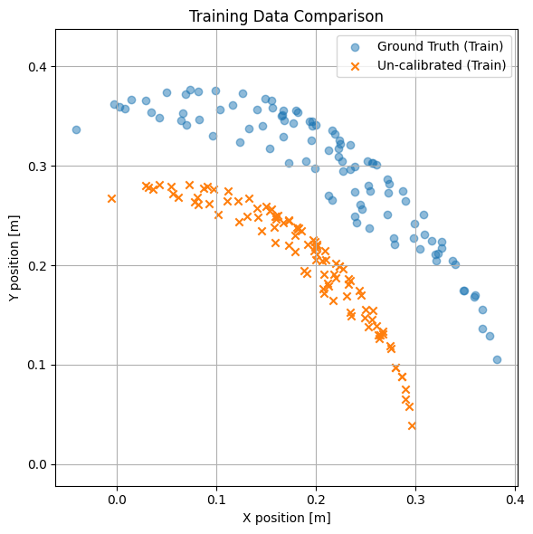

```python
# 초기값 (nominal DH parameters)
a1_nominal = 0.1
a2_nominal = 0.2

# 보정 전 예측 위치 계산
p_pred_nominal = forward_kinematics(theta1_train, theta2_train, a1_nominal, a2_nominal)

# 오차 계산 (L2 norm per sample)
error_nominal = np.linalg.norm(p_pred_nominal - p_train[:2, :], axis=0)

# 평균/최대 오차 출력
print("Calibration 전:")
print(f"평균 오차 (m): {np.mean(error_nominal):.4f}")
print(f"최대 오차 (m): {np.max(error_nominal):.4f}")

plt.figure(figsize=(6, 6))
plt.scatter(p_train[0], p_train[1], label='Ground Truth (Train)', alpha=0.5)
plt.scatter(p_pred_nominal[0], p_pred_nominal[1], label='Un-calibrated (Train)', marker='x')
plt.title('Training Data Comparison')
plt.xlabel('X position [m]')
plt.ylabel('Y position [m]')
plt.axis('equal')
plt.legend()
plt.grid(True)
plt.tight_layout()
plt.show()
```

```
추정된 DH 파라미터:
a1 = 0.0617 m
a2 = 0.3232 m
평균 오차 (m): 0.02735437551874189
최대 오차 (m): 0.05865004958098314
```

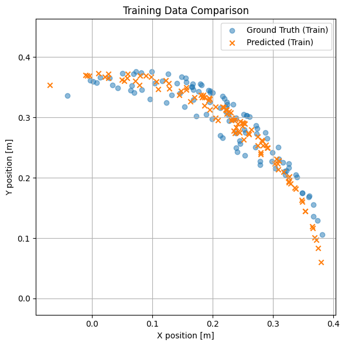

```python
#다른 최적화 알고리즘을 위해 정의
def jacobian(params):
    a1, a2 = params
    c1 = np.cos(theta1_train)
    s1 = np.sin(theta1_train)
    c12 = np.cos(theta1_train + theta2_train)
    s12 = np.sin(theta1_train + theta2_train)

    # 각 샘플에 대해 ∂x/∂a1, ∂x/∂a2, ∂y/∂a1, ∂y/∂a2 계산
    J = np.zeros((2 * len(theta1_train), 2))  # (2N x 2)

    # ∂x/∂a1, ∂x/∂a2
    J[0::2, 0] = c1
    J[0::2, 1] = c12

    # ∂y/∂a1, ∂y/∂a2
    J[1::2, 0] = s1
    J[1::2, 1] = s12

    return J

# residuals 함수: 예측 - 실제
def residuals(params):
    a1, a2 = params
    pred = forward_kinematics(theta1_train, theta2_train, a1, a2)
    diff = pred - p_train  # shape: (2, N)

    # reshape to (2N, ) with interleaved format: [x1, y1, x2, y2, ...]
    return diff.flatten()  # transpose 먼저, 그 다음 flatten

def loss(params):
    a1, a2 = params
    p_pred = forward_kinematics(theta1_train, theta2_train, a1, a2)
    error = p_pred - p_train
    return np.sum(error**2)

# 초기값
x0 = [0.1, 0.2]

# 최적화 실행 (LM 방식)
#res = least_squares(residuals, x0, bounds=([0.05, 0.15], [0.15, 0.35]), method='trf')
res = least_squares(residuals, x0, method='lm')
#res = minimize(loss, x0, method='BFGS')

print("추정된 DH 파라미터:")
print(f"a1 = {res.x[0]:.4f} m")
print(f"a2 = {res.x[1]:.4f} m")

p_pred_train = forward_kinematics(theta1_train, theta2_train, *res.x)

error = np.linalg.norm(p_pred_train - p_train, axis=0)  # 각 샘플별 오차
print("평균 오차 (m):", np.mean(error))
print("최대 오차 (m):", np.max(error))

plt.figure(figsize=(6, 6))
plt.scatter(p_train[0], p_train[1], label='Ground Truth (Train)', alpha=0.5)
plt.scatter(p_pred_train[0], p_pred_train[1], label='Predicted (Train)', marker='x')
plt.title('Training Data Comparison')
plt.xlabel('X position [m]')
plt.ylabel('Y position [m]')
plt.axis('equal')
plt.legend()
plt.grid(True)
plt.tight_layout()
plt.show()
```

## DH Parameter

| link i | $a_i$ | $\alpha_i$ | $d_i$ | $\theta_i$ |
| --- | --- | --- | --- | --- |
| 1 | 0.0617 m | 0 | 0 | $\theta_1$ |
| 2 | 0.3232 m | 0 | 0 | $\theta_2$ |

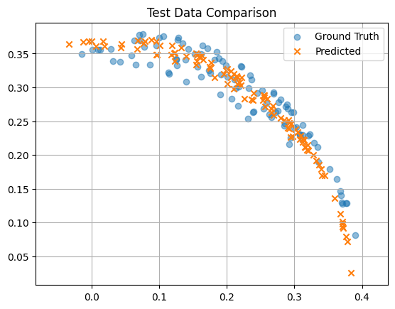

```python
# 테스트 데이터로 성능 확인
theta1_test = data['theta1_test'].flatten()
theta2_test = data['theta2_test'].flatten()
p_test = data['pTest'][:2, :]
p_pred = forward_kinematics(theta1_test, theta2_test, *res.x)

# Plot
plt.scatter(p_test[0], p_test[1], label='Ground Truth', alpha=0.5)
plt.scatter(p_pred[0], p_pred[1], label='Predicted', marker='x')
plt.title('Test Data Comparison')
plt.legend()
plt.axis('equal')
plt.grid()
plt.show()
```

```python
error = np.linalg.norm(p_pred - p_test, axis=0)  # 각 샘플별 오차
print("평균 오차 (m):", np.mean(error))
print("최대 오차 (m):", np.max(error))
```

```
평균 오차 (m): 0.02662555192073213
최대 오차 (m): 0.057668707485150746
```

## 결과

- Calibration을 통해 DH 파라미터를 수정하므로써, Foward kinematic 연산의 오차를 줄일 수 있음.
  - Calibration 전 : 평균 오차 (m): 0.0972 최대 오차 (m): 0.1112
  - Calibration 후 : 평균 오차 (m): 0.0266 최대 오차 (m): 0.0577
- 수정된 DH 파라미터 : 기존 $a_1 = 0.1$, $a_2 = 0.2$

| link i | $a_i$ | $\alpha_i$ | $d_i$ | $\theta_i$ |
| --- | --- | --- | --- | --- |
| 1 | 0.0617 m | 0 | 0 | $\theta_1$ |
| 2 | 0.3232 m | 0 | 0 | $\theta_2$ |

## 오차값에 대한 고찰

※ 오차값이 큰 이유를 확인하기 위해, train data의 최대/최소값을 확인해보면 다음과 같음.

> X 축: 최소값 = -0.0409, 최대값 = 0.3818  
> Y 축: 최소값 = 0.1056, 최대값 = 0.3765

문제에서 주어진 link의 길이가 $a_1 = 0.1 $ , $a_2 = 0.2$ 이나, 두 링크의 길이 합보다 최대/최소값의 크기가 더 크게 나오는 것으로 볼때, simulink의 데이터 생성 과정에서 노이즈 크기를 줄여볼 필요가 있을것 같음.

※ 다른 최적화 알고리즘을 검토해보았으나 (Quasi-Newton) 유의미한 개선은 없음.

```python
min_vals = np.min(p_train, axis=1)
max_vals = np.max(p_train, axis=1)

# 출력
for i, axis in enumerate(['X', 'Y'][:p_train.shape[0]]):
    print(f"{axis} 축: 최소값 = {min_vals[i]:.4f}, 최대값 = {max_vals[i]:.4f}")
```

```
X 축: 최소값 = -0.0409, 최대값 = 0.3818
Y 축: 최소값 = 0.1056, 최대값 = 0.3765
```